# How Enzyme Inhibitors affect enzyme kinetics

# 1. Introduction

## 1.1 Enzymes as Biological Catalysts

### What are Enzymes?

**Background Information**

Enzymes are essential for life and are one of the most important types of protein in the human body. Studying enzyme kinetics provides information about the diverse range of reactions in the human body, which we can use to understand and predict the metabolism of all living things.

Enzymes are incredibly important as biological catalysts. Catalysts do not impact the thermodynamics of a biological reaction; that is, the $\Delta H_{rxn}$ (i.e. the change in enthalpy for a reaction) and equilibrium position do not change. Instead, they help the reaction proceed at a much **faster rate**. As a catalyst, the enzyme is not a reactant, meaning it is not changed during the course of the reaction. Enzymes increase the reaction rate of a process by a factor of 100, 1000, or even 1,000,000,000,000 times as compared to the uncatalyzed reaction. Without this increase, we wouldn’t be alive – it would take years for our bodies to synthesise proteins and other necessary molecules for life.

For any necessary molecule, there's likely to be an enzyme that can speed up the biological reaction associated with it. As such, enzymes are highly diverse in what exactly they do to lower the activation energy of a reaction. Some might expediate chemical reactions by bringing two substrates together in the right orientation, while others may create an environment inside the active site that's favourable to the reaction, such as by making it more acidic.

Enzymes are typically proteins, though some RNA molecules function as enzymes as well.

**Summary of Enzyme Functions:**

1. Lower the activiation energy
2. Increase the rate of reaction
3. Do not alter the equilibrium constant
4. Are not changed or consumed in the reaction (which means that they will appear in both the reactants and products)
5. Are pH- and temperature-sensitive, with optimal acitivity at specific pH ranges and temperatures
6. Do not affect the ΔG (ie Gibbs free energy, or the change in free energy) of the reaction
7. Are specific for a particular reaction or class of reactions

**Enzyme Specificity**

Enzymes are picky. The molecules upon which an enzyme acts are called **substrates**; a given enzyme will only catalyze a single reaction or class of reactions with these substrates, a property known as **enzyme specificity**. For example, urease (enzyme) only catalyzes the breakdown of urea (substrate). Chymotrypsin (a digestive enzyme), on the other hand, can cleave peptide bonds around the amino acids phenylalanine, tryptophan, and tyrosine in a variety of polypeptides. Although those amino acids aren’t identical, they all contain an aromatic ring, which makes chymotrypsin specific for cleaving peptide bonds on aromatic amino acids.

**Enzyme-Substrate Complex**

Enzymes function by binding to their specific reactant molecule(s) at the enzyme's active site, forming a temporary **enzyme-substrate complex**, thus facilitating the chemical bond-breaking and bond-forming processes to occur more readiily. Once the reaction is completed, the product(s) are released, and the enzyme can then be 'reused' to catalyse other reactions, as seen in Figure 1 below.

[figure not shown]

Figure 1, How enzymes work (University of Waikato, 2011)

### Impact on Activation Energy

Enzymes are catalysts that exert their effect by **lowering the activation energy of a reaction**, seen in how the peak of the red line of Figure 2 is lower than that of the green line. In other words, they make it easier for the substrate to reach the transition state. One example of how this happens is when enzymes assist in the orientation of two or more substrates. In this example, the two substrates are molecules that can potentially react, but only when specific parts of each molecule collide with a specific minimum (kinetic) energy level, which is known as an effective collision. Normally, intermolecular collisions are common, but only a fraction of them are effective collisions. Enzymes increase the rate of effective collisions as, when attached to the enzyme's active site, the substrates will always meet in the correct orientation, and the energy threshold, or **activation energy**, is lowered. Imagine having to walk over to the other side of a tall hill – the only way to get there is to climb to the top of the hill and then walk down the other side. But wouldn’t it be easier if the top of the hill was cut off so one wouldn’t have to climb so high? That’s exactly what catalysts do for chemical reactions when they make it easier for substrates to achieve their transition state. Most reactions catalyzed by enzymes are technically reversible, although that reversal may be extremely energetically unfavorable and therefore essentially nonexistent.

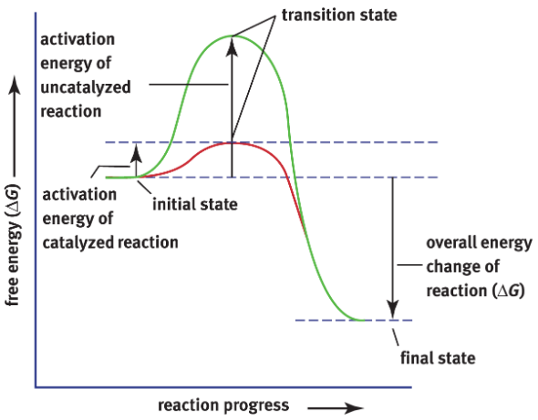

Figure 2, Comparison of activation energy when catalysed by enzyme and when uncatalysed (Prep, 2020)

## 1.2 Regulation of Enzyme Activity

### What are Inhibitors?

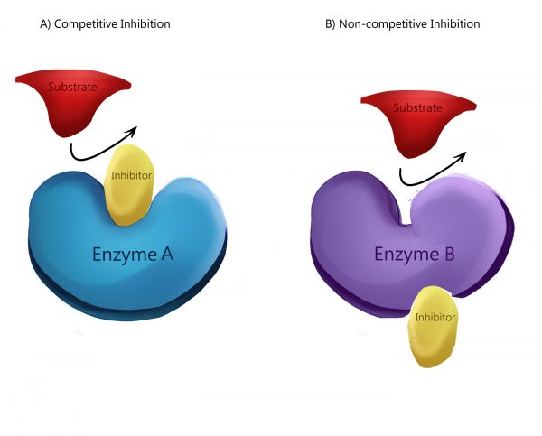

Figure 3, How inhibitors prevent the catalysis of reactions (Teach Me Physiology, 2021)

An enzyme inhibitor is a molecule that binds to an enzyme and decreases its activity. By binding to enzymes' active sites, inhibitors reduce the compatibility of substrate and enzyme and this leads to the **inhibition of Enzyme-Substrate complexes' formation**, preventing the catalysis of reactions and decreasing (at times to zero) the amount of product produced by a reaction. The binding of an inhibitor can stop a substrate from entering the enzyme's active site and/or hinder the enzyme from catalyzing its reaction. (Figure 3) You can think of this process as being similar to a certain Rolls Royce and BMW incident – the BMW acts like the inhibitor by preventing the Rolls Royce substrate from passing through to reach the enzyme, thus causing a jam and slower rate of reaction as other cars (aka substrates) cannot pass through to be catalysed. It can be said that as the concentration of enzyme inhibitors (aka $[I]$) increases, the rate of enzyme activity decreases, and thus, the amount of product produced is inversely proportional to the concentration of inhibitor molecules.

### Competitive Inhibition

In explaining enzyme kinetics and inhibitors, we will be introducing several abbreviations and terms, such as $V_{max}$, $K_m$ and $K_I$, which will be sequentially introduced in the following paragraphs. Do take note of what each entity represents, as they are each significant in our discussion of enzyme kinetics.

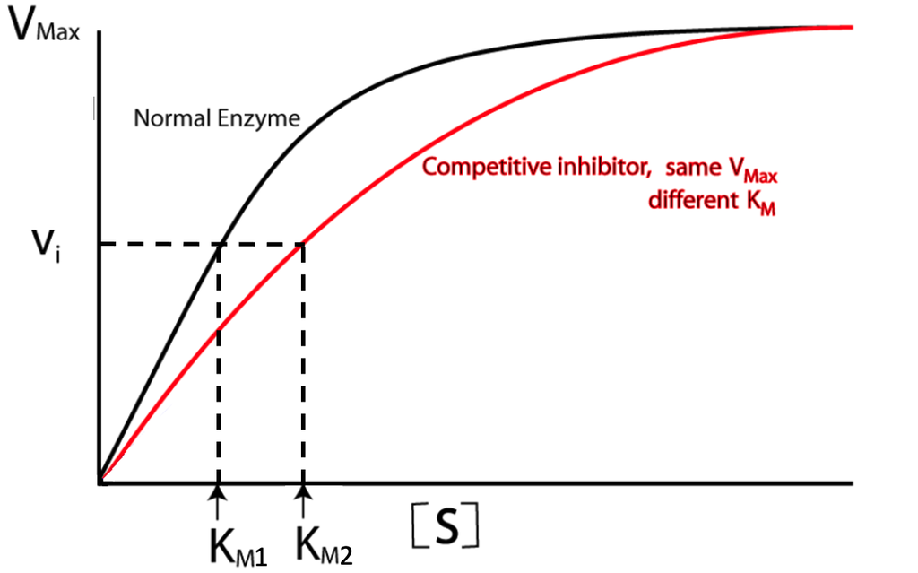

Figure 4, Comparison of rate of reaction without inhibitor versus with competitive inhibitor (The School of Biomedical Sciences, 2018)

**Understanding $V_{max}$**

In enzyme kinetics, $V_{max}$ is the **reaction rate when the enzyme is fully saturated by substrate**, indicating that all the binding sites on the enzymes are being constantly reoccupied, and there are no excess enzyme molecules not involved in the reaction. This is graphically represented in Figure 4 as the plateau of the graphs.

Comparing this to a real-life context, you can imagine that enzymes each have their own parking lot, and all the lots are currently full with cars, AKA the substrate.

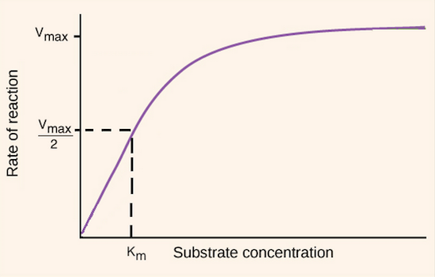

**Understanding $K_m$**

$K_m$ can, therefore, be understood to be the **substrate concentration at which half of the enzyme’s active sites are full.** (Figure 5)

$K_m$ is the **Michaelis constant and is often used to compare enzymes.** Different enzymes have different $K_m$ values.

Under certain conditions, $K_m$ is a measure of the **affinity of the enzyme for its substrate.** When comparing two enzymes, the one with the higher $K_m$ has the lower affinity for its substrate because it requires a higher substrate concentration to be half-saturated – hence $K_m$ is inversely proportional to the affinity an enzyme has for its substrate. (Figure 6) The $K_m$ value is an intrinsic property of the enzyme-substrate system and cannot be altered by changing the concentration of substrate (aka $[S]$) or enzyme.

However, $K_m$ can be altered by changing the concentration of inhibitors (aka $[I]$), as the inhibitors would lower the affinity of the enzyme for its substrates by binding to the enzyme and preventing it from catalysing its substrates.

In summary, $K_m$ = $[S]$ when $\frac{V_{max}}{2}$.

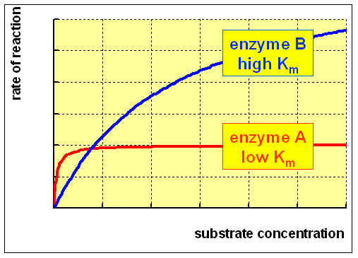

Figure 6, Graphical visualisation of high and low $K_M$ values (University College London, 2022)

**Understanding $K_I$**

The inhibitor constant, $K_I$, is an indication of how potent an inhibitor is; it is the **concentration required to produce half maximum inhibition.**

The smaller the $K_I$, the greater the binding affinity and the smaller amount of inhibitor needed in order to inhibit the activity of that enzyme. If a $K_I$ is much larger than the maximal drug concentrations that a patient is typically exposed to from typical dosing, then that drug is not likely to inhibit the activity of that enzyme.

**Understanding Competitive Inhibition**

Competitive inhibition simply involves occupancy of the active site. (Figure 3) Since substrates are catalysed in the active site, substrates cannot access enzymatic binding sites if there is an inhibitor in the way.

Competitive inhibition can be overcome by adding more substrate so that the substrate-to-inhibitor ratio is higher. If more molecules of substrate are available as compared to molecules of inhibitor, then the enzyme will be more likely to bind to the substrate than the inhibitor (assuming the enzyme has equal affinity for both molecules).

Adding a competitive inhibitor does not alter the value of $V_{max}$ because if enough substrate is added, it will outcompete the inhibitor and be able to run the reaction at maximum velocity.

A competitive inhibitor does increase the measured value of $K_m$. This is because the substrate concentration has to be higher to reach half the maximum velocity in the presence of the inhibitor.

**Most of thrombin's inhibitors are competitive inhibitors**, thus we will focus on competitive inhibition, and will not be discussing non-competitive inhibition.

## 1.3 Thrombin

[figure not shown]

Figure 7, Modelling of thrombin (Proteopedia, 2020)

Our demonstration enzyme is thrombin, which plays a critical role in the process of blood clotting when the body sustains an injury. Being the principal clotting factor, thrombin maintains the balance between bleeding and thrombosis, which occurs when a blood clot forms within a blood vessel which then obstructs the flow of blood in the human circulatory system.

The rate of thrombin activity is crucial in regulating coagulation of blood in both internal and surface injuries, hence it is of interest to be able to chart the generation of thrombin and predict the thrombin dynamics in response to various inhibitors, many of which function as crucial, life-saving medications.

### Functions of Thrombin

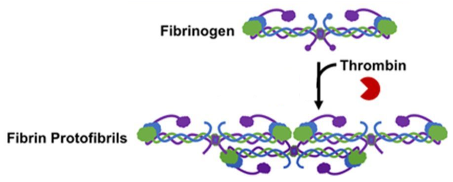

Figure 8, Conversion of Fibrinogen to Fibrin (Department of Pathology and Laborate Medicine, 2017)

Thrombin converts soluble fibrinogen into insoluble strands of fibrin, as well as catalysing many other coagulation-related reactions. The fibrin monomers form covalent bonds with each other to form a fibrin mesh which attracts platelets and phospholipids, thus forming a blood clot and causing hemostasis. Fibrin ultimately forms small fibers that aggregate and cross-link into a woven structure, like a net, that captures red blood cells and other platelets, forming a stable clot over the area of damage.

You can think of this process as thrombin being a cloth-maker – it uses fibrous proteins to weave an organic 'bandage' so as to cover the affected areas.

### The Inhibitors of Thrombin

There are several substances which act as inhibitors for thrombin, such as the inhibitor **Hirudin** and **Heparin**. By inhibiting thrombin, these inhibitors regulate thrombin and limit the blood's ability to clot, thus protecting a person from clotting too much, this is especially useful in the field of medicine as these medications are used to prevent blood clots during and following surgery, or to treat disorders such as acute coronary syndrome (ACS), heart attacks and unstable angina, thus these medications are life-saving for many. If the levels of thrombin inhibitors are low, that person will have a tendency to clot more easily. This is a concern especially when the clots might occur in blood vessels, obstructing normal blood flow.

**Hirudin** is the strongest natural inhibitor of thrombin, and we have chosen it as one of our demonstration inhibitor as it directly binds to and inhibits only the activity of thrombin.

Our other demonstration inhibitor is **Heparin**, which is another widely used drug for patients with heart conditions. While Heparin binds to Antithrombin-III to inhibit thrombin instead of directly to thrombin, it still functions as a competitive inhibitor, hence this detail is not relevant to our discussion.

## 1.4 Goal of the project

In this project, we aim to demonstrate how inhibitors affect enzyme kinetics using simple algorithms. Roughly speaking, the algorithms do so by computing the various rate of reaction of conversion of the soluble fibrinogen into insoluble strands of fibrin with several different inhibitors. With coding, we can test our algorithms quickly, allowing for prompt amendments when necessary.

- **How does changing $K_I$ affect the rate of reaction $V$?** (ie. How does the rate of conversion of fibrin into fibrinogen vary with different inhibitor affinities?)
- **How do each of the Lineweaver-Burk Plots* change with $K_I$?**
- **How do each of the above affect Thrombin - an enzyme that is essential to blood clotting?**

**Note: the Lineweaver-Burk Plots will be elaborated on in greater detail towards the end of this discussion.*

We will revisit these questions as we go through our paper.

## 1.5 Key Terms

1. Enzymes - biological catalysts that are unchanged by the reactions they catalyze and are reusable.
2. Inhibitors - molecule that binds to an enzyme and decreases its activity
3. Competitive Inhibition - results when the inhibitor is similar to the substrate and binds at the active site. Competitive inhibition can be overcome by adding more substrate. $V_{max}$ is unchanged, $K_m$ increases
4. $V$ - Velocity / Rate of Reaction
5. $V_{max}$ - Maximum Velocity (maximum enzyme activity)
6. $K_m$ - Michaelis Constant (Enzyme Affinity)
7. $K_I$ - Dissociation constant of the Enzyme-Inhibitor Complex
8. $[S]$ - Substrate Concentration
9. $[I]$ - Inhibitor Concentration

# 2. Enzyme Kinetics

## 2.1 Michaelis-Menten Equation

The Michaelis–Menten equation is the rate equation for a one-substrate enzyme-catalyzed reaction. This equation relates the reaction rate ($V$), the maximum reaction rate ($V_{max}$), and the substrate concentration $[S]$ through the Michaelis constant $K_m$ — a measure of the substrate-binding affinity.

$$V = \frac{V_{max} [S]}{(1 + \frac{[I]}{K_I})K_m + [S]}$$

```python
#Michaelis-Menten Equation with Inhibitors
def mm(ki, inhib_conc, sub_conc, km, vmax):
    velocity = (vmax * sub_conc) / ((1 + inhib_conc / ki) * km + sub_conc)
    return velocity

#Michaelis-Menten Equation without Inhibitors
def mm_without(sub_conc, km, vmax):
    velocity = (vmax * sub_conc) /  (km + sub_conc)
    return velocity
```

The code above contains our Michaelis-Menten equations based on the aforementioned formula to derive $V$ for each reaction we're studying.

### Michaelis-Menten Plot

For a given concentration of enzyme, the Michaelis–Menten relationship generally graphs as a hyperbola, as seen in the Michaelis–Menten plot. When substrate concentration $[S]$ is less than $K_m$, changes in substrate concentration will greatly affect the reaction rate. At high substrate concentrations exceeding $K_m$, the reaction rate increases much more slowly as it approaches $V_{max}$, where it becomes independent of substrate concentration.

[figure not shown]

Figure 9, Comparison of Michaelis-Menten plots with and without inhibition (MCAT Review, 2018)

```python
#Imports
import numpy as np
import matplotlib.pyplot as plt
from scipy import stats
```

First, we generate arrays for the x- and y-axes, which are substrate concentration $[S]$ and the rate of reaction, $V$, respectively.

We do this by using the equations we have previously defined using the Michaelis-Menten formula. As seen below, we have generated $V$ for the rate of conversion of fibrinogen to fibrin with **thrombin-only** reaction, a thrombin reaction inhibited by **Hirudin**, and a thrombin reaction inhibited by **Heparin**.

The value of $K_m$ for thrombin has been derived to be 2.8 from [Bezeaud et al. (1988). 'Functional characterization of thrombin Salakta: an abnormal thrombin derived from a human prothrombin variant.'](https://doi.org/10.1182/blood.v71.3.556.556)

The value of $V_{max}$ for thrombin has been taken to be 107.5 from a study on adults by [Simpson et al. (2011). 'Simultaneous thrombin and plasmin generation capacities in normal and abnormal states of coagulation and fibrinolysis in children and adults.'](https://doi.org/10.1016/j.thromres.2010.12.011)

The value of $K_I$ for thrombin with Hirudin and Heparin has been derived to be 9.3 and 18 respectively from [Stone, S. R., & Hofsteenge, J. (1987). 'Effect of heparin on the interaction between thrombin and hirudin. European Journal of Biochemistry'](https://doi.org/10.1111/j.1432-1033.1987.tb13622.x)

$K_m$ of thrombin = 2.8 $μM$

$V_{max}$ of thrombin = 107.5 $μM$ $sec^{-1}$

$[I]$ of both Hirudin & Heparin = 30 $μM$

$K_I$ of Hirudin = 9.3 $μM$

$K_I$ of Heparin = 18 $μM$

```python
#Substrate concentration (x-axis) [micromoles]
sub_conc = np.linspace(start = 0, stop = 100, num = 1000, endpoint = True)

#Velocities (y-axis) [micromoles/sec]
v_thrombin = mm_without(sub_conc = sub_conc, km = 2.8, vmax = 107.5)
v_hirudin = mm(ki = 9.3, inhib_conc = 30, sub_conc = sub_conc, km = 2.8, vmax = 107.5)
v_heparin = mm(ki = 18, inhib_conc = 30, sub_conc = sub_conc, km = 2.8, vmax = 107.5)
```

Next, we plot the graphs using the values we have generated from the above equations and values.

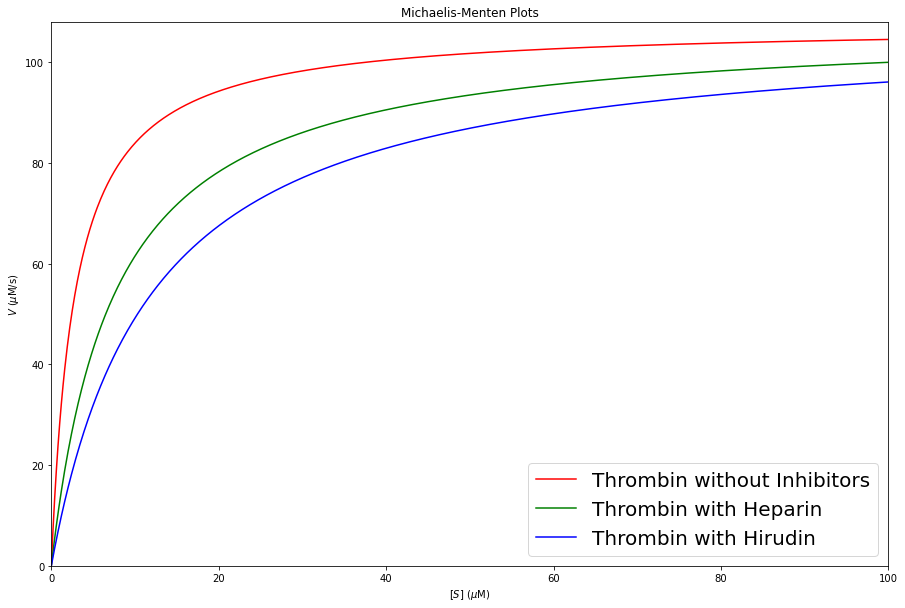

```python
#plotting it out

plt.figure(figsize=(15,10))
plt.plot(sub_conc, v_thrombin, label='Thrombin without Inhibitors', color='red')
plt.plot(sub_conc, v_heparin, label='Thrombin with Heparin', color='green')
plt.plot(sub_conc, v_hirudin, label='Thrombin with Hirudin', color='blue')
plt.xlim([0, 100]) #xlim corresponds to increasing substrate concentrations or [s] values
plt.ylim([0, 108]) #ylim corresponds to vmax values of 107.5
plt.title('Michaelis-Menten Plots')
plt.xlabel('$[S]$ ($\mu$M)')
plt.ylabel('$V$ ($\mu$M/s)')
plt.rcParams['font.size'] = '20'
plt.legend()
plt.show()
```

Tada! A neat graph to visualise our enzyme kinetics.

Evidently, the rate of reaction ($V$) of conversion of fibrinogen to fibrin has been slowed with the addition of Hirudin and Heparin, as the curves increase at a slower rate.

Do note that the $V_{max}$ of all three reactions are the same at $V_{max}$ = 107.5, but due to space constraints the graph does not demonstrate this. With sufficient space, all three graphs will plateau at $V_{max}$ = 107.5

While $V_{max}$ is unchanged by the inhibitors, $K_m$ increases. Remember that $K_m$ is inversely proportional to the affinity of the enzyme for its substrate? The increased $K_m$ with the addition of heparin and Hirudin indicate that this affinity has indeed decreased. As the $K_m$ for Hirudin is greater than heparin, it is indeed a stronger inhibitor for thrombin.

However, a disadvantage is that it is difficult to determine exactly what this difference in $K_m$ is, hence leading us to our next stage of discussion.

### Limitations of the Michaelis-Menten Plot

The disadvantage of the Michaelis-Menten Plot is that it is difficult to determine $V_{max}$ (when unknown) and $K_m$, and often a large amount of $[S]$ is required.

Thus to quantify enzyme kinetics, the Lineweaver-Burk plot (double-reciprocal plot) is the most favoured plot by researchers, as it has two distinct advantages over the Michaelis-Menten plot, in that it gives a more accurate estimate of $V_{max}$ and more accurate information about inhibition. **By linearising the data, it increases the precision of our values**. The values for $K_m$ and $V_{max}$ can thus be determined precisely and the error can be estimated quantitatively.

## 2.2 Lineweaver-Burk Equation

**Background Information**

The Lineweaver-Burk equation is the reciprocal of the Michaelis-Menten equation, meaning $V$ from our equation becomes 1/$V$, so on and so forth. The Lineweaver-Burk equation uses the same entities which we have been using to discuss the Michaelis-Menten equations.

Let's revisit the Michaelis-Menten equation:

$$V = \frac{V_{max} [S]}{(1 + \frac{[I]}{K_I})K_m + [S]}$$

Its reciprocal, AKA the Lineweaver-Burk equation, would be:

$$\frac{1}{V} = \frac{1}{V_{max}} + \big(1 + \frac{[I]}{K_I}\big)\frac{K_m}{V_{max}}\frac{1}{[S]}$$

This new equation is a linearised version of the original Michaelis-Menten equation, meaning that it plots our data on a straight line rather than a curve. This offers many advantages including faster and more accurate data analysis.

We don't need to go into the math of how to derive this reciprocal, as we will be using Python codes to derive it on our behalf from our pre-existing data from the Michaelis-Menten plots.

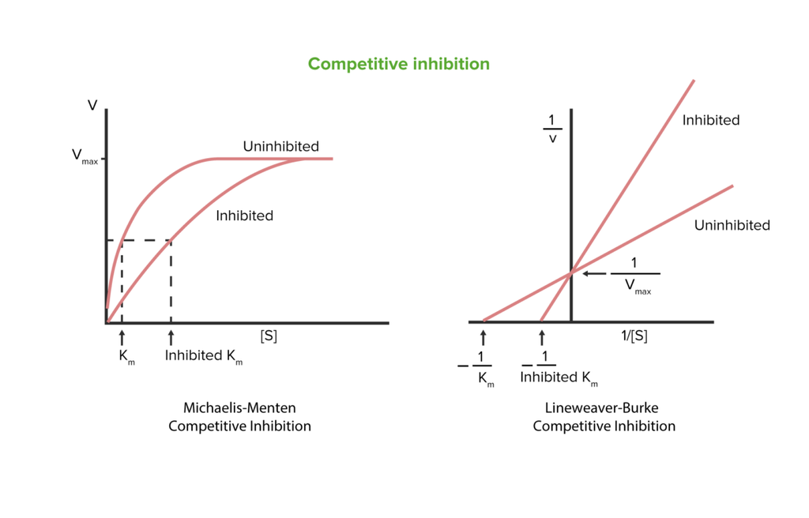

Figure 10, Comparison of Michaelis-Menten and Lineweaver-Burk plots (Lecturio, 2020)

**Making Sense of the Lineweaver-Burk Plots**

Being a linear graph, this equation can be compared with the equation for a straight line: *y = mx + b*, where m is the slope and b is the y-intercept.

In the Lineweaver-Burk equation, $K_m$/$V_{max}$ is the slope (or m), and 1/$V_{max}$ is the y-intercept (or b).

The x-intercept is derived by substituting y=0 into the equation, and is derived to be -1/$K_m$.

For enzymes such as thrombin that obey Michaelis-Menten kinetics, when the reciprocal of the substrate concentration is plotted versus the reciprocal of the velocity (1/$[V]$), results similar to those displayed in the Michaelis-Menten plot are obtained.

The value of 1/$V_{max}$ is obtained by extrapolation to the y-axis, and the maximal velocity corresponds to the velocity at an infinite substrate concentration (1/$[S]$ = 0). The plot also yields -1/$K_m$. Because it is a reciprocal plot, a larger $V_{max}$ corresponds to a smaller value of the ordinate (y-axis value). Similarly, a larger $K_m$ corresponds to a less negative value of the abscissa (horizontal value – along the x-axis). The x-intercept and -1/$K_m$ are negative, and $K_m$ is positive, since a substrate concentration cannot be negative.

The Lineweaver–Burk plot is especially useful when determining the **type of inhibition that an enzyme is experiencing** because $V_{max}$ and $K_m$ can be compared without estimation.

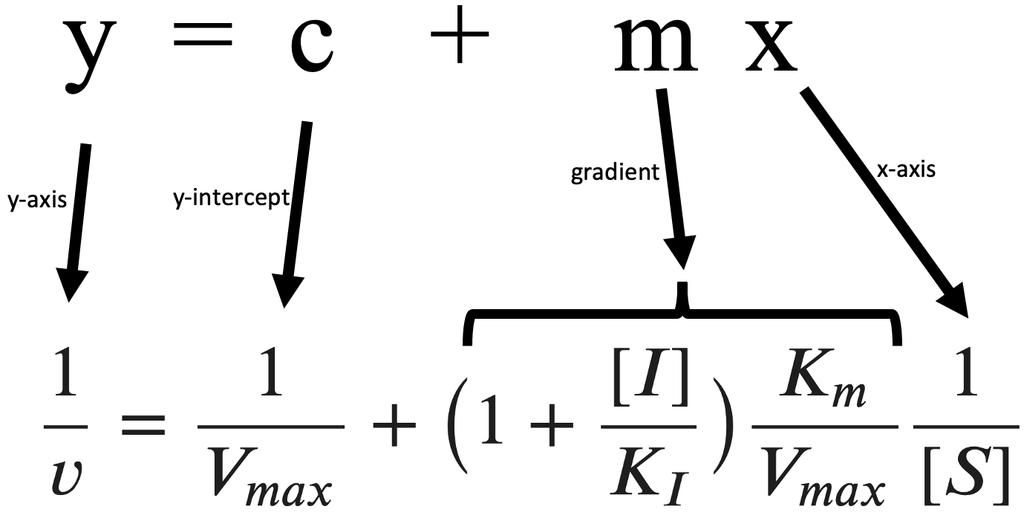

Figure 11, Visualisation of graph

### Lineweaver-Burk Plot

Since the Lineweaver-Burk Plots are basically the recipocral graphs of the MM graphs, we can now easily estimate $K_m$ and $V_{max}$.

First, we used values of substrate concencration, $[S]$, that correspond to values typically tested in lab settings.

```python
#substrate concentration (micromoles) [Experimental Data]
s = np.array([1., 3., 5., 10., 20., 50., 100.]) #values correspond to those typically tested in lab settings

#Generating velocities at corresponding concentration (micromoles/sec)
Thrombin = mm_without(sub_conc = s, km = 2.8, vmax = 107.5)
Hirudin = mm(ki = 9.3, inhib_conc = 30, sub_conc = s, km = 2.8, vmax = 107.5) #these are the same values as in the MM plots
Heparin = mm(ki = 18, inhib_conc = 30, sub_conc = s, km = 2.8, vmax = 107.5) #so are these
```

Next, we're getting the relevant values for the graph to be plotted.

We start with the reciprocal of $[S]$, which is 'x' part of y = mx + c. This is also the x-axis of our new plot.

```python
#Generating statistics
Recip_s = np.reciprocal(s) #here, we're getting the 'x' from y = mx + c
```

The next process is to find the relevant values to plot our Lineweaver-Burk graphs for each of our three equations – thrombin only, thrombin with Hirudin, thrombin with Heparin.

We first find the reciprocal of $V$, ie 1/$V$, which serve as the y-axis values of our new graphs. Subsequently, we need the value of the slope and intercepts, which we can derive using the Scipy function stats.lingress, as demonstrated here:

```
slope, intercept, r_value, p_value, std_err = stats.linregress(x, y)
```

We are only interested in slope and intercept, and we can ignore r_value, p_value and std_err.

Since the intercept given using stats.lingress only returns the y-intercept, we need to derive the x-intercept on our own.

Using y = mx + c, this is done by substituting y = 0, such that $$0 = mx + c$$ $$mx = -c$$ $$x = - \frac{c}{m}$$

To compute this, we must remember that c is the y-intercept and m is the slope, hence the following code:

```
xintercept = ((0-intercept)/slope)
```

Since the x-intercept is also -1/$K_m$, we can derive $K_m$ by taking the negative reciprocal of the x-intercept, hence:

```
Km = (-1 / xintercept)
```

We carry out these steps for each of the three reactions beind studied.

```python
#Statistics for Thrombin
Recip_vT = np.reciprocal(Thrombin) #reciprocal of V for Thrombin
slopeT, interceptT, r_valueT, p_valueT, std_errT = stats.linregress(Recip_s, Recip_vT) #to find value of slope & y-intercept
xinterceptT = ((0 - interceptT)/slopeT) #when y=0, x = (0-c)/m
KmT = (-1 / xinterceptT) #x-intercept = -1/Km

#Statistics for Thrombin with Hirudin
Recip_vHiru = np.reciprocal(Hirudin) #reciprocal of V for Hirudin
slopeHiru, interceptHiru, r_valueHiru, p_valueHiru, std_errHiru = stats.linregress(Recip_s, Recip_vHiru)
xinterceptHiru = ((0 - interceptHiru)/slopeHiru)
KmHiru = (-1 / xinterceptHiru)

#Statistics for Thrombin with Heparin
Recip_vHepa = np.reciprocal(Heparin) #reciprocal of V for Heparin
slopeHepa, interceptHepa, r_valueHepa, p_valueHepa, std_errHepa = stats.linregress(Recip_s, Recip_vHepa)
xinterceptHepa = ((0 - interceptHepa)/slopeHepa)
KmHepa = (-1 / xinterceptHepa)
```

Following which, we plot everything out.

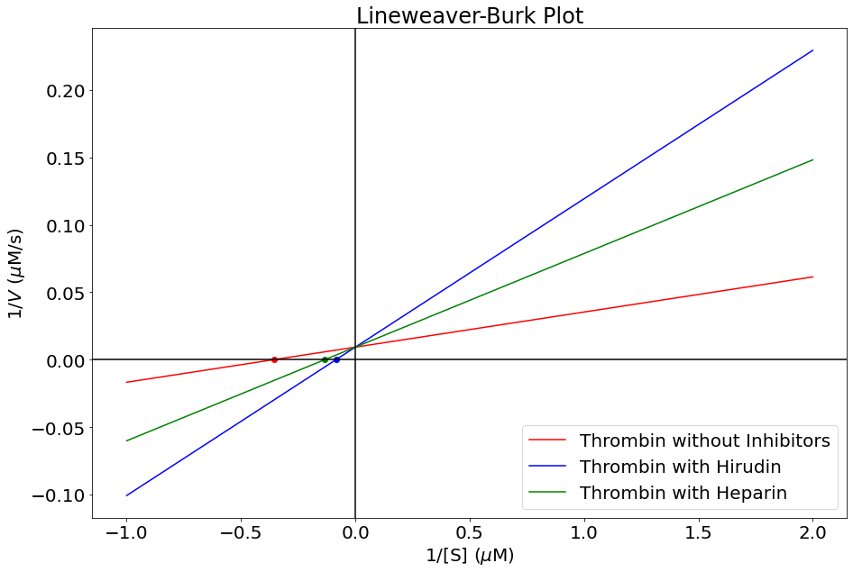

```python
#Plotting it out
plt.figure(figsize=(15,10))

#Thrombin without Inhibitors
xT = np.linspace(-1., 2., 1000)
yT = (slopeT * xT) + interceptT
plt.scatter(xinterceptT, 0, color='red')
plt.plot(xT, yT, label='Thrombin without Inhibitors', color='red')

#Thrombin with Antithrombin
xHiru = np.linspace(-1., 2., 1000)
yHiru = (slopeHiru * xHiru) + interceptHiru
plt.scatter(xinterceptHiru, 0, color='blue')
plt.plot(xHiru, yHiru, label='Thrombin with Hirudin', color='blue')

#Thrombin with Heparin
xHepa = np.linspace(-1., 2., 1000)
yHepa = (slopeHepa * xHepa) + interceptHepa
plt.scatter(xinterceptHepa, 0, color='green')
plt.plot(xHepa, yHepa, label='Thrombin with Heparin', color='green')

#Titles and labels and axis
plt.axhline(0, color='black')
plt.axvline(0, color='black')
plt.xlabel('1/[S] ($\mu$M)')
plt.ylabel('1/$V$ ($\mu$M/s)')
plt.title('Lineweaver-Burk Plot')
plt.rcParams['font.size'] = '20'
plt.legend()
plt.show()
```

So much easier to compare $K_m$ and $V_{max}$ now!

Evidently, from this plot we can tell that $V_{max}$ for all three equations remains unchanged, as all three graphs intersect at the same point on the y-axis.

We have placed circle markers where the graphs intersect the x-axis. These values are each graphs' respective -1/$K_m$ values, and we can easily derive $K_m$ by taking the negative reciprocal of these x-intercepts.

We have printed the values in the next set of code, and all the information is neatly summarised in a table at the end.

```python
#Finding Ratio of Km to Vmax (Thrombin without Inhibitors)
print("\n----Values for Thrombin without Inhibitors----")
print("1/Vmax Thrombin = ", "{:.2f}".format(interceptT))
print("Vmax Thrombin = ", "{:.2f}".format(1/interceptT))
print("\n-1/Km Thrombin = ", "{:.2f}".format(xinterceptT))
print("Km Thrombin = ", "{:.2f}".format(KmT))
print("\nKm/Vmax Thrombin (slope (Thrombin)): ", "{:.2f}".format(slopeT)) #here this is the we're getting the 'm' from y = mx + c

#Finding Ratio of Km to Vmax (Thrombin with Hirudin)
print("\n----Values for Thrombin with Hirudin----")
print("1/Vmax Hirudin = ", "{:.2f}".format(interceptHiru))
print("Vmax Hirudin = ", "{:.2f}".format(1/interceptHiru))
print("\n-1/Km Hirudin = ", "{:.2f}".format(xinterceptHiru))
print("Km Hirudin = ", "{:.2f}".format(KmHiru))
print("\nKm/Vmax Hirudin (slope (Hirudin)): ", "{:.2f}".format(slopeHiru)) #here this is the we're getting the 'm' from y = mx + c

#Finding Ratio of Km to Vmax (Thrombin with Heparin)
print("\n\n----Values for Thrombin with Heparin----")
print("1/Vmax Heparin = ", "{:.2f}".format(interceptHepa))
print("Vmax Heparin = ", "{:.2f}".format(1/interceptHepa))
print("\n-1/Km Heparin = ", "{:.2f}".format(xinterceptHepa))
print("Km Heparin = ", "{:.2f}".format(KmHepa))
print("\nKm/Vmax Heparin (slope (Heparin)): ", "{:.2f}".format(slopeHepa)) #here this is the we're getting the 'm' from y = mx + c

Vmax_recip = [interceptT, interceptHiru, interceptHepa]
Km_recip = [xinterceptT, xinterceptHiru, xinterceptHepa]
slope = [slopeT, slopeHiru, slopeHepa]

print("\n\nThe above information is summarised in the table below.")

# This prints the title
print("\n\n" f"{'Table of 1/Vmax, Vmax, -1/Km, Km across Thrombin samples with various inhibitors':^80}")

# This starts the table
print(f"\n{'-'*83:^83}")
print(f"{'Inhibitor':^15} | {'1/Vmax':^15} | {'Vmax':^7} | {'-1/Km':^7} | {'Km':^7} | {'Slope (Km/Vmax)':^15} |")
print(f"{'-'*83:^83}")

for i, sample in enumerate(['No Inhibitors', 'Hirudin', 'Heparin']):
    print(f"{sample:^15} | {round(Vmax_recip[i],2):^15} | {round(1/Vmax_recip[i],2):^7} | {round(Km_recip[i],2):^7} | {round(-1/Km_recip[i],2):^7} | {round(slope[i],2):^15} |")

print(f"{'-'*83:^83}")
```

```
----Values for Thrombin without Inhibitors----
1/Vmax Thrombin =  0.01
Vmax Thrombin =  107.50

-1/Km Thrombin =  -0.36
Km Thrombin =  2.80

Km/Vmax Thrombin (slope (Thrombin)):  0.03

----Values for Thrombin with Hirudin----
1/Vmax Hirudin =  0.01
Vmax Hirudin =  107.50

-1/Km Hirudin =  -0.08
Km Hirudin =  11.83

Km/Vmax Hirudin (slope (Hirudin)):  0.11


----Values for Thrombin with Heparin----
1/Vmax Heparin =  0.01
Vmax Heparin =  107.50

-1/Km Heparin =  -0.13
Km Heparin =  7.47

Km/Vmax Heparin (slope (Heparin)):  0.07


The above information is summarised in the table below.


Table of 1/Vmax, Vmax, -1/Km, Km across Thrombin samples with various inhibitors

-----------------------------------------------------------------------------------
   Inhibitor    |     1/Vmax      |  Vmax   |  -1/Km  |   Km    | Slope (Km/Vmax) |
-----------------------------------------------------------------------------------
 No Inhibitors  |      0.01       |  107.5  |  -0.36  |   2.8   |      0.03       |
    Hirudin     |      0.01       |  107.5  |  -0.08  |  11.83  |      0.11       |
    Heparin     |      0.01       |  107.5  |  -0.13  |  7.47   |      0.07       |
-----------------------------------------------------------------------------------
```

Finally, exact values which we can use to compare all three reactions. The $K_m$ of Hirudin is the highest at 11.83 as compared to that of Heparin and thrombin only, which are at 7.47 and 2.80 respectively. Remember how $K_m$ represents the Michaelis constant, and are used to compare enzymes? Now that we have exact values, we can easily quantify the reactions we are studying.

## 2.3 Key Observations

Let us revisit the key questions we have listed out earlier:

1. **How does changing $K_I$ affect the rate of reaction $V$?** (ie. How does the rate of conversion of fibrin into fibrinogen vary with different inhibitor affinities?)
2. **How do each of the Lineweaver-Burk Plots* change with $K_I$?**
3. **How do each of the above affect Thrombin - an enzyme that is essential to blood clotting?**

Below are a list of key observations for competitive inhibition that you should notice, in response to the above key questions:

**In competitive inhibition as with the case of thrombin's inhibitors:**

1. $K_I$ affects enzyme-substrate activity signficantly at lower concentrations of substrate, however the inhibition can be overcome with a large enough $[S]$ (i.e., the Michaelis-Menten graph will eventually reach $V_{max}$)
2. Changing $K_I$ alters the gradient of the Lineweaver-Burk plot: the smaller the $K_I$, the greater the gradient of the Lineweaver-Burk plot. In other words, the stronger the inhibitor, the steeper the slope of the Lineweaver-Burk plot.
3. Changing $K_I$ does not alter the y-intercept ($V_{max}$)

# 3. Future Works

There is potential to further explore the effects other inhibitors have on thrombin, particularly those which require a binding cofactor such as antithrombin. There is also potential to examine the half-life and long-term effects of various inhibitors on thrombin, and compare the results against each other.

There is also potential also explore the effect of Heparin on the interaction between thrombin and Hirudin, should both medication be consumed at the same time.

Another possible extension is to explore non-competitive inhibitors of thrombin, which, while less common, could offer more options to allow for more acute regulation of thrombin for the treatment of various cardiovascular and blood-related diseases.

# 4. References

Alberts, B., Heald, R., Johnson, A., Morgan, D., Raff, M., Roberts, K., Walter, P., Wilson, J., & Hunt, T. (2022). Molecular Biology of the Cell (Seventh ed.). W. W. Norton & Company.

Bezeaud, A., Elion, J., & Guillin, M. (1988). Functional characterization of thrombin Salakta: an abnormal thrombin derived from a human prothrombin variant. Blood, 71(3), 556–561. https://doi.org/10.1182/blood.v71.3.556.556

de Laat-Kremers, R. M. W., Yan, Q., Ninivaggi, M., de Maat, M., & de Laat, B. (2020). Deciphering the coagulation profile through the dynamics of thrombin activity. Scientific Reports, 10(1). https://doi.org/10.1038/s41598-020-69415-y

Durrani, J., Malik, F., Ali, N., & Jafri, S. I. (2018). To be or not to be a case of heparin resistance. Journal of Community Hospital Internal Medicine Perspectives, 8(3), 145–148. https://doi.org/10.1080/20009666.2018.1466599

*Enzymes*. Molecular Biology: Enzymes - MCAT Review. (2018). Retrieved March 30, 2022, from https://mcat-review.org/enzymes.php

G. (2022). Biochemistry by Garrett, Reginald H., Grisham, Charles M.. (Cengage Learning,2012) [Hardcover] 5th Edition. BroksCole, Hardcover(2012).

Hirsh, J., Anand, S. S., Halperin, J. L., & Fuster, V. (2001). Mechanism of action and pharmacology of unfractionated heparin. Arteriosclerosis, Thrombosis, and Vascular Biology, 21(7), 1094–1096. https://doi.org/10.1161/hq0701.093686

Jordan, R., Oosta, G., Gardner, W., & Rosenberg, R. (1980). The kinetics of hemostatic enzyme-antithrombin interactions in the presence of low molecular weight heparin. Journal of Biological Chemistry, 255(21), 10081–10090. https://doi.org/10.1016/s0021-9258(19)70431-1

Kattula, S., Byrnes, J. R., & Wolberg, A. S. (2017). Fibrinogen and Fibrin in Hemostasis and Thrombosis. Arteriosclerosis, Thrombosis, and Vascular Biology, 37(3). https://doi.org/10.1161/atvbaha.117.308564

Nelson, D. L., & Cox, M. M. (2021). Lehninger Principles of Biochemistry (Eighth ed.). W. H. Freeman.

*Non-competitive inhibitor*. Non-competitive inhibitor - The School of Biomedical Sciences Wiki. (2018, October 20). Retrieved March 30, 2022, from https://teaching.ncl.ac.uk/bms/wiki/index.php/Non-competitive_inhibitor

Oiseth, S., Jones, L., & Maza, E. (2021, January 8). Enzyme inhibition: Concise medical knowledge. Lecturio. Retrieved March 30, 2022, from https://www.lecturio.com/concepts/enzyme-inhibition/

Prep, K. T. (2020a). MCAT Biochemistry Review 2021–2022: Online + Book (Kaplan Test Prep) (Proprietary ed.). Kaplan Test Prep.

Prep, K. T. (2020b). MCAT Biology Review 2021–2022: Online + Book (Kaplan Test Prep) (Proprietary ed.). Kaplan Test Prep.

Prep, K. T. (2020c). MCAT General Chemistry Review 2021–2022: Online + Book (Kaplan Test Prep) (Proprietary ed.). Kaplan Test Prep.

Rosing, J., Tans, G., Govers-Riemslag, J., Zwaal, R., & Hemker, H. (1980). The role of phospholipids and factor Va in the prothrombinase complex. Journal of Biological Chemistry, 255(1), 274–283. https://doi.org/10.1016/s0021-9258(19)86294-4

Rye, C., Wise, R., Jurukovski, V., DeSaix, J., Choi, J., & Avissar, Y. (2016, October 16). Ch. 1 introduction - biology. OpenStax. Retrieved March 30, 2022, from https://openstax.org/books/biology/pages/1-introduction

Sato, H., & Nakajima, A. (1984). Kinetic study on the initial stage of the fibrinogen-fibrin conversion by thrombin (II) Application of enzyme kinetics to turbidimetrical method. Thrombosis Research, 35(2), 133–139. https://doi.org/10.1016/0049-3848(84)90208-1

Simpson, M. L., Goldenberg, N. A., Jacobson, L. J., Bombardier, C. G., Hathaway, W. E., & Manco-Johnson, M. J. (2011). Simultaneous thrombin and plasmin generation capacities in normal and abnormal states of coagulation and fibrinolysis in children and adults. Thrombosis Research, 127(4), 317–323. https://doi.org/10.1016/j.thromres.2010.12.011

STONE, S. R., & HOFSTEENGE, J. (1987). Effect of heparin on the interaction between thrombin and hirudin. European Journal of Biochemistry, 169(2), 373–376. https://doi.org/10.1111/j.1432-1033.1987.tb13622.x

What is an inhibitory constant (Ki) and how does it relate to understanding drug interactions? (2015, October). The Inhibitory Constant (Ki) and Its Use in Understanding Drug Interactions. https://www.ebmconsult.com/articles/inhibitory-constant-ki-drug-interactions